# Matplotlib Part-1

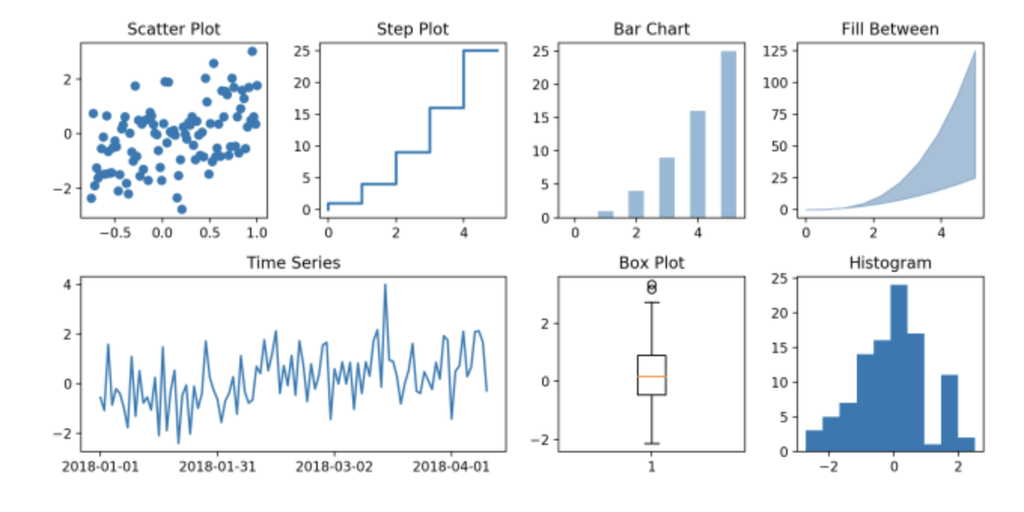

```python
from IPython.display import Image
Image(filename='charts.png',width=700, height=300)
```

## 1. Scatter Plot

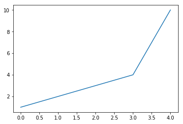

```python
import matplotlib.pyplot as plt
import matplotlib as mpl
import numpy as np
%matplotlib inline

# plot
plt.plot([1,2,3,4,10])
```

plt.plot drew a line plot. it is default behavior. This format is a short hand combination of {color} {marker} {line}.

- 'r*--' : ‘red stars with dashed lines’
- 'ks.' : ‘black squares with dotted line’ (‘k’ stands for black)
- 'bD-.' : ‘blue diamonds with dash-dot line’.

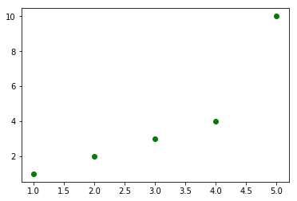

```python
# green dots:
plt.plot([1,2,3,4,5], [1,2,3,4,10], 'go')
plt.show()
```

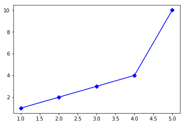

```python
plt.plot([1,2,3,4,5], [1,2,3,4,10], 'bD-')
plt.show()
```

## 2. Scatterplots in same plot

Plotting another set of 5 points of different color in the same figure.

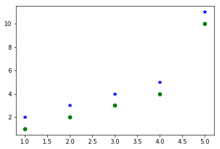

```python
# Draw two sets of points
plt.plot([1,2,3,4,5], [1,2,3,4,10], 'go')
plt.plot([1,2,3,4,5], [2,3,4,5,11], 'b*')
plt.show()
```

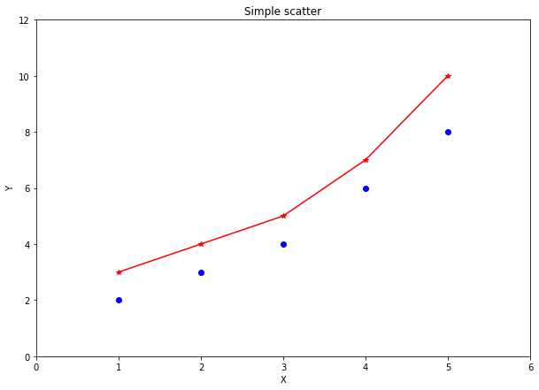

```python
plt.figure(figsize=(10,7))
plt.plot([1,2,3,4,5], [2,3,4,6, 8], 'bo', label='blue')
plt.plot([1,2,3,4,5], [3,4,5,7,10], 'r*-', label='red')
plt.title('Simple scatter')
plt.xlabel('X')
plt.ylabel('Y')
plt.xlim(0,6)
plt.ylim(0,12)
plt.show()
```

- Color:

blue: b ,green: g ,red: r, cyan: c, magenta: m, yellow: y, black: k, white: w

## 3. Draw 2 scatterplots in different panels

I want the points drawn on different subplots (axes). I have to call the plot function in the respective axes (ax1 and ax2) instead of plt. Below code, ax1.plot() and ax2.plot() instead of calling plt.plot() twice.

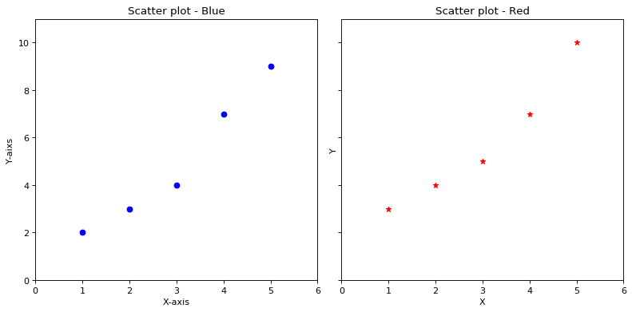

```python
# Create figure and subplots
fit, (ax1, ax2) = plt.subplots(1,2, figsize=(10, 5), sharey=True, dpi=80)

# plot
ax1.plot([1,2,3,4,5], [2,3,4,7,9], 'bo')
ax2.plot([1,2,3,4,5], [3,4,5,7, 10], 'r*')

# title, X and Y labels, X and Y lim
ax1.set_title('Scatter plot - Blue')
ax2.set_title('Scatter plot - Red')
ax1.set_xlabel('X-axis')
ax1.set_ylabel('Y-aixs')
ax2.set_xlabel('X')
ax2.set_ylabel('Y')
ax1.set_xlim(0,6); ax1.set_ylim(0,11)
ax2.set_xlim(0,6); ax2.set_ylim(0,11)

# ax2.yaixs.set_ticks_postion('none')
plt.tight_layout()
plt.show()
```

Setting 'shary=True' in plot.subplots() shares the Y axis between toe two subplot. dpi is increase the number of dots per inch of the plot. I can drwo this instead of it using below operations.

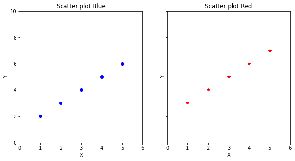

```python
fig, (ax1, ax2) = plt.subplots(1,2, figsize=(10,5), sharey=True)

ax1.plot([1,2,3,4,5], [2,3,4,5,6], 'bo')
ax2.plot([1,2,3,4,5], [3,4,5,6,7], 'r*')

# title, xlabel, ylabel, xlim, ylim
ax1.set(title='Scatter plot Blue', xlabel='X', ylabel='Y', xlim=(0, 6), ylim=(0,10))
ax2.set(title='Scatter plot Red', xlabel='X', ylabel='Y', xlim=(0,6), ylim=(0,10))

plt.show()
```

## 4. Bar chart

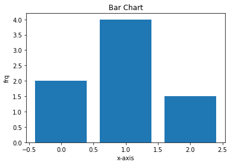

```python
y=[2,4,1.5]
x=np.arange(len(y))
plt.bar(x,y)
xlabel=['A', 'B', 'C']
plt.title('Bar Chart')
plt.ylabel("frq")
plt.xlabel('x-axis')
plt.show()
```

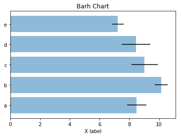

```python
np.random.seed(0)

char = ['a', 'b', 'c','d','e']
y_axis = np.arange(len(char))
performance = 3 + 10 * np.random.rand(len(y_axis))
error = np.random.rand(len(char)) # Adding error bar

plt.title('Barh Chart')
plt.barh(y_axis, performance, xerr=error, alpha=0.5)
plt.yticks(y_axis, char)
plt.xlabel('X label')
plt.show()
```

```python
error
```

```
array([0.64589411, 0.43758721, 0.891773  , 0.96366276, 0.38344152])
```

```python
performance
```

```
array([ 8.48813504, 10.15189366,  9.02763376,  8.44883183,  7.23654799])
```

```python
y_pos
```

[output not shown]

## 5. Stem plot

A stem plot has vertical line using 'linefmt' at each x location from the baseline to y, and places a marker there using markerfmt. A horizontal line at zero is plotted using basefmt.

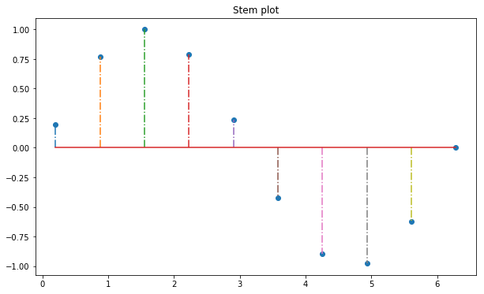

```python
x = np.linspace(0.2, 2 * np.pi, 10)

plt.figure(figsize=(10,6))
plt.title('Stem plot')
plt.stem(x, np.sin(x), '-.')
plt.show()
```

```python
x
```

```
array([0.2       , 0.87590948, 1.55181896, 2.22772844, 2.90363791,
       3.57954739, 4.25545687, 4.93136635, 5.60727583, 6.28318531])
```

## 6. Pie Chart

Make a pie chart of array x. The fractional area of each wedge is given by x/sum(x). If sum(x) <= 1, then the values of x give the fractional area directly and the array will not be normalized. The wedges are plotted counterclockwise, by default starting from the x-axis.

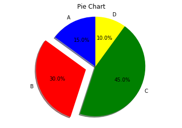

```python
labels = ['A', 'B', 'C', 'D']
size = [15, 30, 45, 10]
colors=['blue', 'red', 'green', 'yellow']
explode = (0, 0.2, 0, 0)

plt.title('Pie Chart')
plt.pie(size, explode = explode, labels = labels, colors = colors, autopct='%1.1f%%', shadow=True, startangle=90)
plt.axis('equal')
plt.show()
```

## 7. Histogram

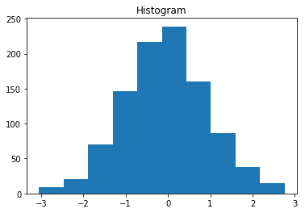

```python
np.random.seed(0)
x = np.random.randn(1000)
plt.title('Histogram')
arrays, bins, patches = plt.hist(x, bins=10)
plt.show()
```

```python
arrays
```

```
array([  9.,  20.,  70., 146., 217., 239., 160.,  86.,  38.,  15.])
```

```python
bins
```

```
array([-3.04614305, -2.46559324, -1.88504342, -1.3044936 , -0.72394379,
       -0.14339397,  0.43715585,  1.01770566,  1.59825548,  2.1788053 ,
        2.75935511])
```

## Modify the Axis Ticks postions and labels

1. Tick Label: Using 'plt.xticks()' or 'ax.setxticks()' and 'ax.setxticklabel()'
1. Axis's ticks (top/bottom/ left/ right) : Using 'plt.tick_params()'
1. Functional formatting of Tick Labels
- If we are using 'ax', we can use 'ax.set_xticks()' and 'ax.set_xticklabels()' to set the positions and label texts.
- If we are using the 'plt', we can set both the positions as well as the label text in one call using the 'plt.xticks()'

The code of plt.xticks() method, it calls ax.set_xticks() and ax.set_xticklabels() to do the job. plt.xticks takes the ticks and labels as required parameters but I can also adjust the label’s fontsize, rotation, ‘horizontalalignment’ and ‘verticalalignment’ of the hinge points on the labels, like below.

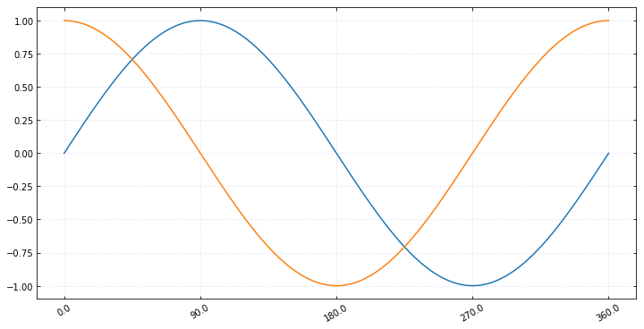

```python
from matplotlib.ticker import FuncFormatter

def rad_to_degrees(x, pos):
    'converts radians to degrees'
    return round(x * 57.2985, 2)

plt.figure(figsize=(12, 6))
X = np.linspace(0,2*np.pi,1000)
plt.plot(X,np.sin(X))
plt.plot(X,np.cos(X))

# 1. Adjust x axis Ticks
# 1 radian = 57.2985 degrees
plt.xticks(ticks=np.arange(0, 440/57.2985, 90/57.2985), fontsize=10, rotation=30, ha='center', va='top')

# 2. Tick Parameters
plt.tick_params(axis='both',bottom=True, top=True, left=True, right=True, direction='in', which='major', grid_color='blue')

# 3. Format tick labels to convert radians to degrees
formatter = FuncFormatter(rad_to_degrees)
plt.gca().xaxis.set_major_formatter(formatter)
plt.grid(linestyle='--', linewidth=0.5, alpha=0.15)
plt.show()
```

## Colors

Matplotlib comes with pre-built colors and palettes.

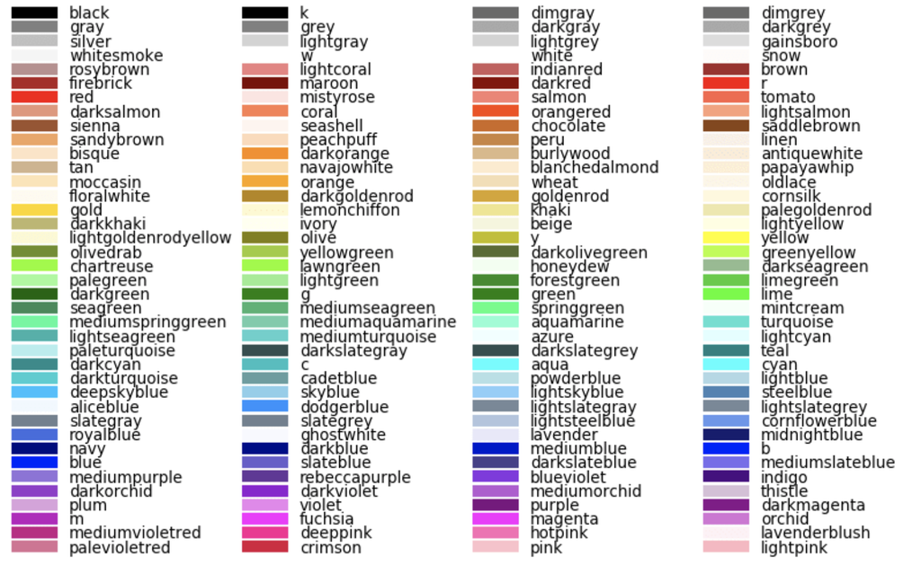

```python
Image(filename='colors.png', width=800, height=300)
```

```python
# View colors
#mpl.colors.CSS4_COLORS
```

```python
#mpl.colors.XKCD_COLORS
```

```python
mpl.colors.BASE_COLORS
```

```
{'b': (0, 0, 1),
 'g': (0, 0.5, 0),
 'r': (1, 0, 0),
 'c': (0, 0.75, 0.75),
 'm': (0.75, 0, 0.75),
 'y': (0.75, 0.75, 0),
 'k': (0, 0, 0),
 'w': (1, 1, 1)}
```

```python
dir(plt.cm)[:10]
```

```
['Accent',
 'Accent_r',
 'Blues',
 'Blues_r',
 'BrBG',
 'BrBG_r',
 'BuGn',
 'BuGn_r',
 'BuPu',
 'BuPu_r']
```

## Customise the legend

The common way to make a legend is to define the label parameter for each of the plots using 'plt.legend()'.

- plt.legend((line1, line2, line3), ('label1', 'label2', 'label3'))

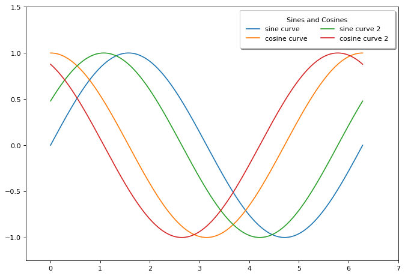

```python
# plt.style.use('seaborn-notebook')
plt.figure(figsize=(10,7), dpi=80)
X = np.linspace(0, 2*np.pi, 1000)
sine = plt.plot(X,np.sin(X)); cosine = plt.plot(X,np.cos(X))
sine_2 = plt.plot(X,np.sin(X+.5)); cosine_2 = plt.plot(X,np.cos(X+.5))
plt.gca().set(ylim=(-1.25, 1.5), xlim=(-.5, 7))

# Modify legend

plt.legend([sine[0], cosine[0], sine_2[0], cosine_2[0]],   # plot items
           ['sine curve', 'cosine curve', 'sine curve 2', 'cosine curve 2'],
           frameon=True,                                   # legend border
           framealpha=1,                                   # transparency of border
           ncol=2,                                         # num columns
           shadow=True,                                    # shadow on
           borderpad=1,                                    # thickness of border
           title='Sines and Cosines')                      # title
plt.show()
```

## Adding texts, arrows and annotations

- plt.text()
- plt.annotate()

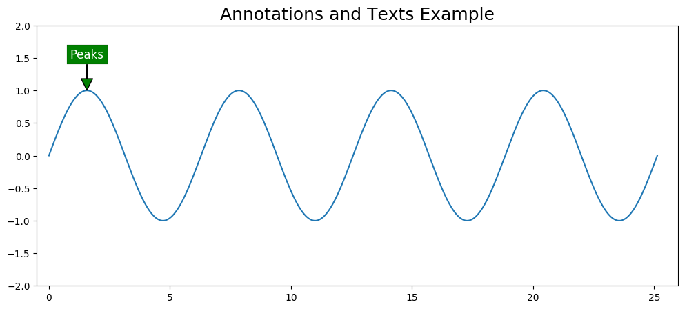

```python
# Texts, Arrows and Annotations Example
# ref: https://matplotlib.org/users/annotations_guide.html
plt.figure(figsize=(12,5), dpi=100)
X = np.linspace(0, 8*np.pi, 1000)
sine = plt.plot(X,np.sin(X), color='tab:blue');

# 1. Annotate with Arrow Props and bbox
plt.annotate('Peaks', xy=(90/57.2985, 1.0), xytext=(90/57.2985, 1.5),
             bbox=dict(boxstyle='square', fc='green', linewidth=0.1),
             arrowprops=dict(facecolor='green', shrink=0.01, width=0.1),
             fontsize=12, color='white', horizontalalignment='center')

# 2. Texts at Peaks and Troughs
'''
for angle in [440, 810, 1170]:
    plt.text(angle/57.2985, 1.05, str(angle) + "\ndegrees", transform=plt.gca().transData, horizontalalignment='center', color='green')

for angle in [270, 630, 990, 1350]:
    plt.text(angle/57.2985, -1.3, str(angle) + "\ndegrees", transform=plt.gca().transData, horizontalalignment='center', color='red')

'''
plt.gca().set(ylim=(-2.0, 2.0), xlim=(-.5, 26))
plt.title('Annotations and Texts Example', fontsize=18)
plt.show()
```

## Customize subplots layout

Tow convenient ways to create customized multi-subplots layout. Blow two operation is draw complex layouts.

- plt.subplot2grid : A helper function that is similar to subplot() but uses 0-based indexing and let subplot to occupy multiple cells.
- plt.GridSpec

### (1) subplot2grid

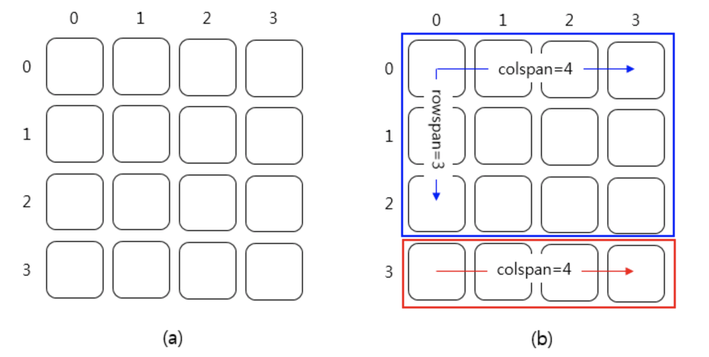

```python
Image(filename = 'subplot.png', width=700, height=500)
```

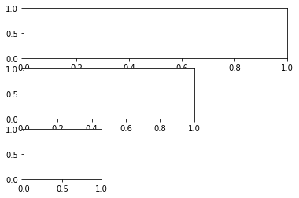

```python
ax2 = plt.subplot2grid((3,3), (0,0), colspan=3)
ax3 = plt.subplot2grid((3,3), (1,0), colspan=2)
ax4 = plt.subplot2grid((3,3), (2, 0), colspan=1)
plt.show()
```

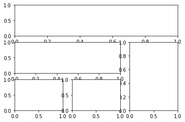

```python
ax1 = plt.subplot2grid((3,3), (0,0), colspan=3)
ax2 = plt.subplot2grid((3,3), (1,0), colspan=2)
ax3 = plt.subplot2grid((3,3), (1,2), rowspan=2)
ax4 = plt.subplot2grid((3,3), (2,0))
ax5 = plt.subplot2grid((3,3), (2,1))
```

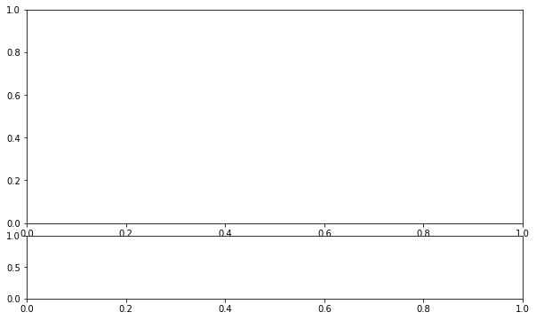

```python
plt.figure(figsize=(10,6))
ax1 = plt.subplot2grid((4,4), (0,0), rowspan=3, colspan=4) # Top
ax2 = plt.subplot2grid((4,4), (3,0), rowspan=1, colspan=4) # Bottom
plt.show()
```

### (2) plt.GridSpec

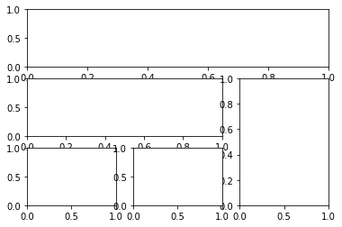

```python
import matplotlib.gridspec as gridspec

gs = gridspec.GridSpec(3,3)
ax1 = plt.subplot(gs[0, :])
ax2 = plt.subplot(gs[1, :-1])
ax3 = plt.subplot(gs[1: , -1])
ax4 = plt.subplot(gs[-1, 0])
ax5 = plt.subplot(gs[-1, -2])
```